# Faza 2

Patrycja Matys, Jan Rosa, Krzysztof Rutkowski, Magda Sobiczewska

31 maja 2016

## Wprowadzenie

W prezentacji pokażemy w jaki sposób staraliśmy się wybrać model predykcji odsetka zachorować na raka piersi w danym powiecie. Korzystając z analiz dokonanych w pierwszej fazie projektu zdecydowaliśmy się robić model wyłączenie dla kobiet. Za czynniki mogące wpływać na odsetek zachorowań wybraliśmy:

- gęstość zaludnienia
- urbanizację
- stężenie szkodliwych substancji w powietrzu
- uciążliwe warunki pracy
- tereny zielone
- strukturę wiekową

Używaliśmy następujących metod:

- regresja liniowa
- knn z selekcją cech
- SVM
- random forest dla regresji
- random forest ze zdyskretyzowaną zmienną decyzyjną za pomocą klastrowania

Przy użyciu metody walidacji polegającej na 10-krotnym próbkowaniu zbioru testowego w stosunku 1:3 (zbiór testowy:zbiór treningowy) uzyskaliśmy następujące wyniki (wszystkie wyniki pomnożone przez 10<sup>7</sup>, zapis “knn *liczba* *metoda*” oznacza liczbę sąsiadów oraz metodę użytą do selekcji cech):

| metoda | MSE |
| --- | --- |
| knn 10 rank | 1.52 |
| knn 5 rank | 1.54 |
| regresja liniowa | 1.68 |
| regresja aic | 1.70 |
| knn 10 chi | 1.77 |
| knn 5 chi | 1.79 |
| regresja lasso | 1.80 |
| regresja grzbietowa | 1.81 |
| lasy losowe dla regresji | 2.10 |
| SVM | 2.45 |
| regresja pcr | 3.10 |
| lasy losowe dla klasyfikacji | 4.20 |

Widzimy, że najlepiej sprawdziały się knn i regresja liniowa. Te metody omówimy szerzej.

## Przygotowanie danych

Do predykcji przygotowaliśmy dane dotyczące powiatów, gdzie zmienną objaśnianą jest znormalizowany (przez liczbę kobiet w powiecie) odsetek kobiet chorych na raka piersi. Zaś zmiennymi objaśniającymi są czynniki wymienione wyżej.

```r
load(file = "clean_znorm.RData")
kable(head(clean.all.data[,1:6]))
```

| TERYT | PYLY | GAZY | GESTOSC | URBANIZACJA | ZAGROZENIA |
| --- | --- | --- | --- | --- | --- |
| 0201 | 0.0424333 | 35.182004 | 69.00000 | 0.0424333 | 611.00000 |
| 0202 | 0.0466267 | 54.059151 | 221.00000 | 0.0466267 | 577.66667 |
| 0203 | 0.3212933 | 3145.680211 | 204.00000 | 0.3212933 | 4923.00000 |
| 0204 | 0.0298133 | 7.219061 | 50.00000 | 0.0298133 | 90.33333 |
| 0205 | 0.0429533 | 42.809278 | 90.33333 | 0.0429533 | 713.33333 |
| 0206 | 0.0786833 | 71.919724 | 104.00000 | 0.0786833 | 310.66667 |

```r
kable(head(clean.all.data[,7:12]))
```

| ZIELONE | LICZBA_ZACHOROWAN | wiek0_44 | wiek45_54 | wiek55_64 | wiek65_74 |
| --- | --- | --- | --- | --- | --- |
| 611.00000 | 0.0028652 | 0.5549883 | 0.1313902 | 0.1541395 | 0.0794502 |
| 577.66667 | 0.0028056 | 0.5052401 | 0.1353015 | 0.1632849 | 0.0860499 |
| 4923.00000 | 0.0024947 | 0.5632951 | 0.1277781 | 0.1758353 | 0.0739757 |
| 90.33333 | 0.0022683 | 0.5749622 | 0.1268633 | 0.1407431 | 0.0699935 |
| 713.33333 | 0.0030594 | 0.5391344 | 0.1382935 | 0.1576636 | 0.0720748 |
| 310.66667 | 0.0023898 | 0.5251596 | 0.1351343 | 0.1756568 | 0.0716046 |

## Metody

### Regresja liniowa

Za pomocą regresji liniowej sprawdziliśmy na początek, które czynniki są rzeczywiście istotne. Wyniki testu t pokazują, że za istotne należy uznać:

- gęstość zaludnienia
- urbanizację

Przy bardziej tolerancyjnym poziomie istotności ważne również będzie stężenie szkodliwych substancji.

```
##
## Call:
## lm(formula = LICZBA_ZACHOROWAN ~ . - TERYT - PYLY - wiek85 -
##     sredni, data = clean.all.data)
##
## Residuals:
##        Min         1Q     Median         3Q        Max
## -1.036e-03 -2.475e-04 -1.381e-05  2.609e-04  1.959e-03
##
## Coefficients: (1 not defined because of singularities)
##               Estimate Std. Error t value Pr(>|t|)
## (Intercept)  6.507e-03  9.019e-03   0.721  0.47109
## GAZY         4.898e-09  2.902e-09   1.688  0.09234 .
## GESTOSC      1.395e-07  4.229e-08   3.298  0.00107 **
## URBANIZACJA -4.965e-05  1.998e-05  -2.485  0.01338 *
## ZAGROZENIA   2.794e-08  1.515e-08   1.844  0.06598 .
## ZIELONE             NA         NA      NA       NA
## wiek0_44    -7.303e-03  9.181e-03  -0.795  0.42688
## wiek45_54   -6.034e-03  8.323e-03  -0.725  0.46896
## wiek55_64    1.081e-02  9.391e-03   1.152  0.25026
## wiek65_74    1.115e-02  9.323e-03   1.196  0.23232
## wiek75_84   -2.231e-02  1.312e-02  -1.701  0.08980 .
## ---
## Signif. codes:  0 '***' 0.001 '**' 0.01 '*' 0.05 '.' 0.1 ' ' 1
##
## Residual standard error: 0.0003911 on 369 degrees of freedom
## Multiple R-squared:  0.592,  Adjusted R-squared:  0.5821
## F-statistic: 59.49 on 9 and 369 DF,  p-value: < 2.2e-16
```

Mimo, że test t wskazał iż żaden z czynników dotyczących struktury wiekowej nie jest istotny statystycznie , to test F udowodnił iż cała ta grupa zmiennych jest istotna.

```
##
##  F test to compare two variances
##
## data:  fit and fit1
## F = 0.59824, num df = 369, denom df = 374, p-value = 8.743e-07
## alternative hypothesis: true ratio of variances is not equal to 1
## 95 percent confidence interval:
##  0.4880245 0.7334437
## sample estimates:
## ratio of variances
##          0.5982373
```

Potwierdza to również model w którym zamiast grup wiekowych użyto tylko średniego wieku mieszkańców powiatu.

```
##
## Call:
## lm(formula = LICZBA_ZACHOROWAN ~ GAZY + sredni + GESTOSC + URBANIZACJA +
##     ZAGROZENIA, data = clean.all.data)
##
## Residuals:
##        Min         1Q     Median         3Q        Max
## -1.201e-03 -3.498e-04  3.220e-06  3.479e-04  1.945e-03
##
## Coefficients:
##               Estimate Std. Error t value Pr(>|t|)
## (Intercept) -2.470e-03  6.740e-04  -3.664 0.000284 ***
## GAZY         5.154e-09  3.505e-09   1.470 0.142301
## sredni       1.245e-04  1.690e-05   7.364 1.15e-12 ***
## GESTOSC      3.055e-07  4.735e-08   6.453 3.41e-10 ***
## URBANIZACJA -9.093e-06  2.372e-05  -0.383 0.701699
## ZAGROZENIA   5.792e-08  1.756e-08   3.299 0.001063 **
## ---
## Signif. codes:  0 '***' 0.001 '**' 0.01 '*' 0.05 '.' 0.1 ' ' 1
##
## Residual standard error: 0.0004731 on 373 degrees of freedom
## Multiple R-squared:  0.3965, Adjusted R-squared:  0.3884
## F-statistic: 49.01 on 5 and 373 DF,  p-value: < 2.2e-16
```

Następnie porównaliśmy metody predykcji, wielkorotnie trenując model wylosowanej z danych próbce. Najpierw porównano bardziej klasyczne metody:

- regresje liniową z maksymalną liczbą parametrów
- regresje z liczbą parametrów wskazaną przez kryterium Akaike
- regresje grzbietową i lasso wykorzystując wszytskie parametry
- metodę PCA wykorzystując 4 wektory PCR

Wykres przedstawia porównanie błędów przy próbkowaniach dla trzech metod, średni MSE dla wszytskich metod przedstawia tablela.

### Wybór metody

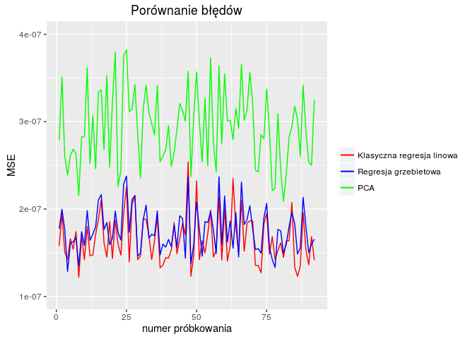

Jak widać, za najlepsza metodę predykcji musimy na razie uznać zwykłą regresję liniową.

Wizualne przedstawienie wyników uzyskanych metodą regresji

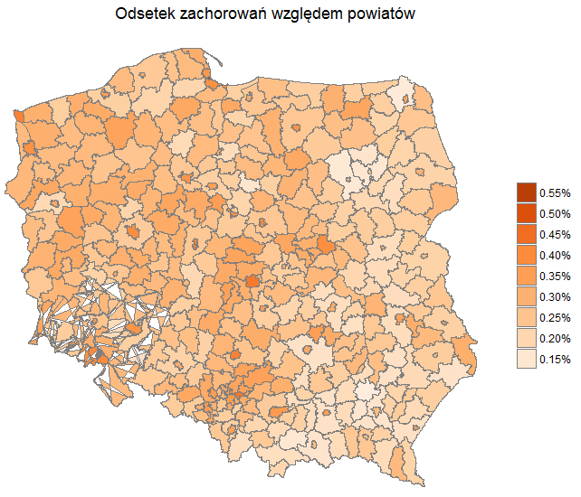

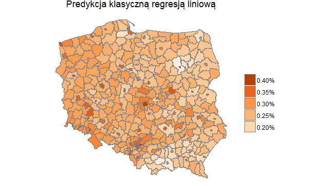

### KNN

Algorytm knn zastosowaliśmy w dwóch krokach:

1. Stworzyliśmy ranking cech korzystając z:
- testu niezależności chi-kwadrat
- testu korelacji rankingowej (korelacja Spearmana)
2. Zastosowaliśmy algorytm knn dla wybranych, najlepszych cech

stosując metrykę ważoną przez wagi uzyskane w selekcji atrybutów

Kod metryki:

```r
dist <- function(x, y, weights) {
  return(sum(weights * abs(x-y)))
}
```

Ranking cech na podstawie selekcji rank:

```r
load("weights_rank.RData")
kable(weights.rank)
```

|  | attr_importance |
| --- | --- |
| PYLY | 0.4828877 |
| GAZY | 0.4873420 |
| GESTOSC | 0.4428157 |
| URBANIZACJA | 0.4828877 |
| ZAGROZENIA | 0.3914113 |
| ZIELONE | 0.3914113 |
| wiek0_44 | 0.5069878 |
| wiek45_54 | 0.1918788 |
| wiek55_64 | 0.6867289 |
| wiek65_74 | 0.4085760 |
| wiek75_84 | 0.0465691 |
| wiek85 | 0.1424324 |
| sredni | 0.4123784 |

Badaliśmy wyniki uzyskane z analizy 5 i 10 najlepszych sąsiadów. Jako metodę głosowania wśród zbioru sąsiadów wybraliśmy średnią.

Wizualne przedstawienie wyników uzyskanych metodą KNN

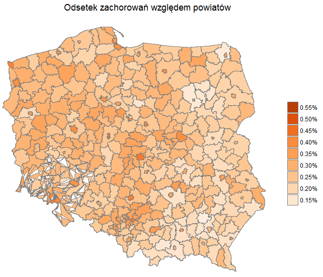

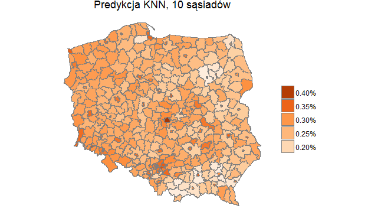

## Podsumowanie

Wyniki uzyskane metodą regresji jak i KNN są dość zbliżone, jednak lepsze uzyskujemy metodą knn, gdyż ma większą siłę predykcyjną, ale działa dużo wolniej i nie mamy gotowego modelu. Z analiz selekcji atrybutów dla knn, jak i analizy regresji widać, że najistotniejszymi cechami z punktu widzenia predykcji odsetka zachorowań są urbanizacja, gęstość zaludnienia, struktura wiekowa oraz zanieczyszczenia.